# A Fully Bayesian Analysis of Broman’s Socks

Bayesian

Discrete Probability

When Karl Broman tweeted about his laundry he likely didn’t imagine that people would still be estimating how many socks he washed 7 years later. In this post my willingness to derive some exact formulae will enable a fully Bayesian, sampling free, approach to laundry quantification.

> That the 1st 11 socks in the laundry are each distinct suggests there are a lot more socks. [pic.twitter.com/EGSo9P6rw7](http://t.co/EGSo9P6rw7)

> — Karl Broman (@kwbroman) [October 17, 2014](https://twitter.com/kwbroman/status/523221976001679360?ref_src=twsrc%5Etfw)

I belatedly found my way to the puzzle of estimating exactly how many socks Karl Broman washed through Rasmus Bååth’s excellent [blog post](http://www.sumsar.net/blog/2014/10/tiny-data-and-the-socks-of-karl-broman/), which uses the problem to illustrate Approximate Bayesian Computation.

Rasmus wraps-up the post by presenting three potential criticisms of his analysis, of which one is *Why use approximate Bayesian computation at all?* I’ll take up his challenge and derive an explicit formula for the likelihood function, enabling a Bayesian analysis without the need for sampling methods.

I’ll also propose an alternative model to take into account my personal belief that the Tweet was sent in the knowledge that the twelfth sock was going to break the run of distinct socks!

## Assumptions

This post makes some assumptions about you: that you have some experience with (or a willingness to learn) statistics and discrete probability.

I’ll assume that you’re familiar twith the concepts of Bayesian statistics: a model (the *likelihood*) describes our understanding of how some data is generated, it can be combined with initial assumptions about plausible parameter values (*prior distributions*) and combining these with observed data leads to refined assumptions (*posterior distributions*).

To follow the derivation of the likelihood you’ll need to know some common constructs from discrete probability/combinatorics: e.g. understanding of binomial coefficients, and how these relate to counting problems.

## Bååth’s Model

Our aim is to estimate the total number of socks that Karl Broman washed given his Tweet that the first 11 removed from the washing machine were distinct.

I’ll use the following notation throughout:

I use the convention that *data* is denoted by letters from the Roman alphabet, whilst unknown *parameters* use the Greek alphabet.

$$\begin{align*} \bf{\text{Data}}\\
d & = \text{No. successive distinct socks observed before Tweeting}\\
\\
\bf{\text{Parameters}}\\
\rho & = \text{No. pairs of socks in the wash}\\
\sigma & = \text{No. singleton socks in the wash} \\
\end{align*}$$

For the specific case of the Tweet we have $d = 11$.

Using two parameters $\rho$ and $\sigma$ allows us to handle the scenario that whilst most socks come in pairs, in some households stray singleton socks are not uncommon. We do however assume socks don’t come in multiples of more than two (excluding the not-uncommon scenario in which two pairs of identical socks are washed).

The likelihood, $L(d|\rho,\sigma)$, describes how the unknown parameters generate the obsered data: *Assuming there were $\rho$ pairs of socks and $\sigma$ singletons how likely is it that the first $d$ socks are all distinct?*

As a warm up for deriving a complete formula, let’s consider some of the edge cases which have fun logical heuristics:

| Scenario | Heuristic | Likelihood $L(d\|\rho,\sigma)$ |
| --- | --- | --- |
| $\rho, \, \sigma < 0$ | Let’s not be silly: you can’t have negative socks. | 0 |
| $d > 2\rho + \sigma$ | We can’t observe more socks than were washed. | 0 |
| $d > \rho + \sigma$ | We can’t observe more **distinct** socks than the number of distinct socks that were washed. | 0 |
| $\rho = 0, \, \sigma \geq d$ | If all the socks were different, then of course all the observed socks are different. | 1 |

With the edge cases handled, let’s press on and handle the substantive problem.

Likelihood
$$L(\rho,\sigma|d) =
\binom{2\rho + \sigma}{d}^{-1} \sum_{j=0}^{\sigma} 2^{d-j} \binom{\sigma}{j} \binom{\rho}{d-j}$$

Examples
$$L(\rho,\sigma|d) =
\binom{2\rho + \sigma}{d}^{-1} \sum_{j=0}^{\sigma} 2^{d-j} \binom{\sigma}{j} \binom{\rho}{d-j}$$

As a *soft* check that the formula above is correct, let’s take a look at some specific cases.

#### Example: $\bf{\rho = 1, \, \sigma = 1, \,d = 2}$.

This is the smallest non-trial scenario, and we can check this easily by hand. If we denote the socks by {S,P1,P2}, there are three ways to choose two of them: {S,P1}, {S,P2} and {P1,P2}. In two of the scenarios the socks are distinct, so the likelihood is 2/3.

#### Example: $\bf{\rho=3,\,\sigma=4, \, d = 4}$

Whilst this example doesn’t sound much more complex, crunching numbers directly would be pretty tedious (admittedly, tricky) as the denominator of the likelihood formula suggests there are 210 scenarios to check.

Evaluating the formula for these parameters indicates the likelihood is 129/210 ~ 0.614.

We can quickly validate this by simulating drawing four socks from 3 pairs and 4 singletons, and calculating the proportion of the draws that produced distinct socks.

```r
set.seed(1414214)

rho <- 3
sigma <- 4
d <- 4

# vector of all the socks
all_socks <- c(rep(paste0("P",1:rho), 2), paste0("S", 1:sigma))

# a function to sample d socks without replacement from all_socks, and return
# 1 if all socks are distinct, and 0 otherwise
sample_socks <- function(all_socks, d){
  sock_sample <- sample(x = all_socks, size = d, replace = FALSE)
  return( 1 * (length(sock_sample) == length(unique(sock_sample))) )
}

# draw samples
draws <- tibble(draw = map_dbl(1:1e05, ~sample_socks(all_socks, d)))
```

| Summary |  |
| --- | --- |
| No. Draws | 100,000 |
| No. All Distinct | 61,360 |
| Prob. All Distinct | 0.614 |

Proof

$$L(\rho,\sigma|d) =
\binom{2\rho + \sigma}{d}^{-1} \sum_{j=0}^{\sigma} 2^{d-j} \binom{\sigma}{j} \binom{\rho}{d-j}$$

#### Proof

In words, the likelihood is given by the following fraction

$$\frac{\text{No. ways to choose d }{\bf{distinct}}\text{ socks from $\rho$ pairs and $\sigma$ singletons.}}{\text{No. ways to choose d socks from $\rho$ pairs and $\sigma$ singletons.}}$$

Starting with the denominator, this is none other than the total number of ways to choose $d$ objects without replacement from a total of $2 \rho + \sigma$ (the factor of two is because $\rho$ pairs of socks equates to $2 \rho$ individual socks). That is given by the binomial coefficient $\binom{2\rho + \sigma}{d}$, and explains the leading term in the likelihood formula above.

Turning to the numerator, I’ll break this down by conditioning on the number of singleton socks. I.e. we’ll count

$$\text{No. of ways to choose $d$ distinct socks, given that $j$ of them are singletons.}$$

Starting with the sigletons, there are $\binom{\sigma}{j}$ ways to choose exactly $j$ of these. The remaining $d-j$ socks need to come from the pairs, there are $\rho$ distinct socks that form $2\rho$ pairs, so there are $\binom{\rho}{d-j}$ ways to choose the *type* of socks. But then for each of these $d-j$ socks we need an additional factor of 2 as we could have chosen between two (left, and right?) socks. Bringing this together, we have:

$$2^{d-j}\binom{\rho}{d-j}\binom{\sigma}{j}.$$

The full formula for numerator, and then the likelihood, follows by summing over the possible values of $j = 0,\ldots,\sigma$.

For a similar proof, I previously posted an answer to a question on [Cross Validated](https://stats.stackexchange.com/questions/469677/closed-form-of-pairing-probability/469707#469707) with a slightly different sock related problem.

In practice when evaluating the likelihood (and later the posterior distribution) there are some computational tricks we employ to avoid running into problems of integer overlflow; these are detailed in the end-notes.

In the plot below we visualise the likelihood for the case of interest, $d = 11$.

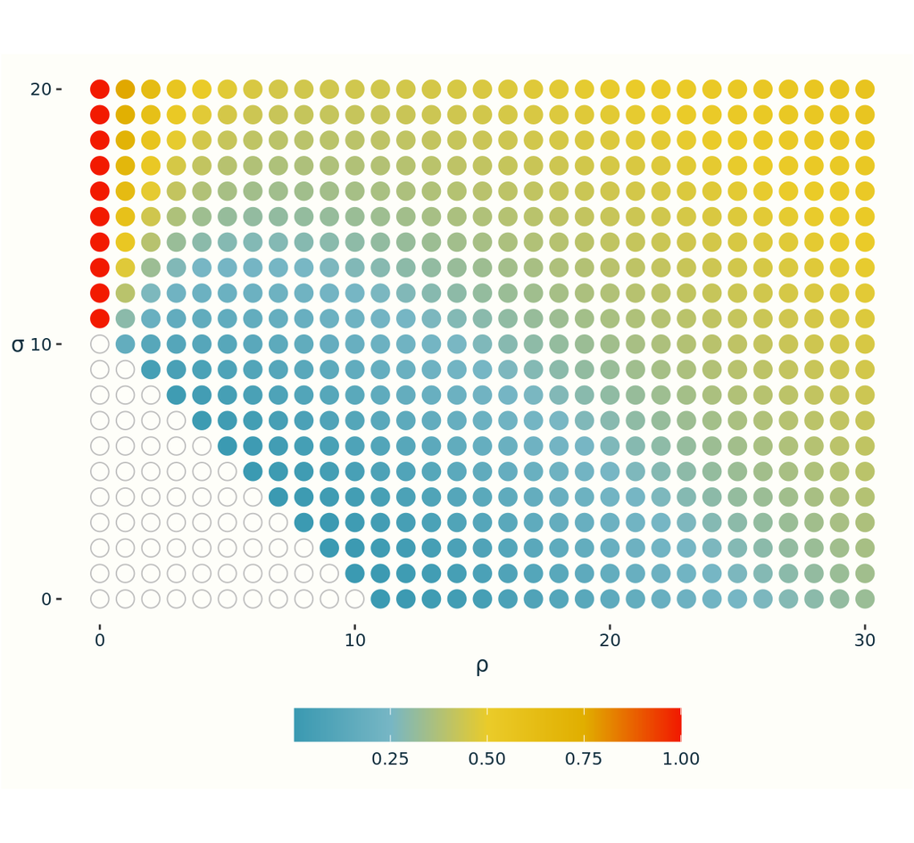

```r
# log likelihood for Baath's model
baath_log_likelihood <- function(rho, sigma, d){

  # it is not possible to choose more than p+s distinct socks
  if(d > rho + sigma) return(-Inf)

  # log summation terms, for the log-sum-exp trick.
  log_summation_terms <- purrr::map(0:min(d, sigma), function(j){
    (d-j)*log(2) + lchoose(sigma,j) + lchoose(rho,d-j)
  })

  log_likelihood <- -lchoose(2*rho + sigma,d) +  logSumExp(log_summation_terms)

  return(log_likelihood)
}

# compute grid of likelihood values, fix d = 11
baath_likelihood_grid <- calculate_sock_grid(30, 20, log_likelihood = function(rho,sigma){baath_log_likelihood(rho,sigma,d=11)})

# plot likelihood grid
plot_sock_grid(baath_likelihood_grid, var = likelihood)
```

Bååth’s Likelihood

The plot demonstrates why a frequentist, maximum likelihood estimate (MLE) approach to solving this problem is bound to fail: the likelihood is maximised, and equal to 1, in all the scenarios that $\sigma \geq 11$, and $\rho = 0$.

Even if we introduced a constraint that $\rho > 0$, this just pushes MLE to return a solution at the limits $\rho,\sigma \rightarrow \infty$.

## From Prior to Posterior

To avoid getting stuck in trivial edge scenarios, I’ll introduce a prior distribution over $(\rho,\sigma)$, and conduct a Bayesian Analysis. The prior captures our beliefs about the number of socks in the washing machine, in absence of any data.

I’ll put separate priors on the number of singleton and pairs of socks, and then add a restriction that the total socks can’t exceed a fixed (large) amount. This differs from Rasmus’ approach, but produces formulae that are easier to work with: since Rasmus was using sampling, complexity in the formulae wasn’t an issue.

It is possible to derive a formula for Rasmus’ prior - but its messy! For the really invested, see the footnotes.

Capping the maximum number of socks will be required to get an exact value for the normalising constant that turns up in using Bayes rule. If we denote $p(\rho,\sigma)$ for the prior distribution, $p(\rho, \sigma) |d)$ for the posterior distribution, and $L(d|\rho,\sigma)$ the likelihdood as before, then Bayes rule gives

$$p(\rho,\sigma | d) = Z^{-1}L(d | \rho, \sigma) p(\rho,\sigma), \qquad \text{where } Z = \sum_{\rho,\sigma} L(d | \rho, \sigma) p(\rho,\sigma).$$
By constraining the prior to a finite range the normalising constant $Z$ can be calculated without estimating tail behaviour. This capping is hardly restrictive: after all in practice washing machines can’t hold arbitrarily many socks!

The prior distribution on $\rho$ and $\sigma$ should be a discrete distribution, on the positive integers. Like Rasmus I’ll use Negative Binomial distributions, which are a flexible generalisation of the Poisson distribution, allowing us to separately control the mean and variance.

I’ll choose parameters for the Negative Binomial distributions so that that the marginal distributions of the product prior closely match those of Rasmus’ prior, which [he derived](http://www.sumsar.net/blog/2014/10/tiny-data-and-the-socks-of-karl-broman/#prior-sock-distributions) based on assumptions about the plausible amount of washing a family might produce. This leads to me using the priors:

Parameters were found using the Method of Moments and then rounded to give *nice* values

$$\rho \sim \text{NegBinom}\left(3 \frac{1}{4}, \frac{1}{5}\right), \qquad \sigma \sim \text{NegBinom}\left(2, \frac{1}{3}\right),$$

I’ll also cap the maximum number of socks that could plausibly have been washed at 300. Googling the average weight of a sock returns a range of estimates, but I’ll errr on the lower side and say a sock ways 50g. 300 socks would therefore come in at 15kg, which is the maximum drum size of any domestic washing machine I could find on Amazon!

Writing out the prior explicitly gives:

$$p(\rho,\sigma) = \textstyle \mathbf{\large 1}_{2\rho + \sigma \leq 300} \, \times \, \binom{\rho + 2\frac{1}{4}}{\rho} \left(1 - \frac{1}{5}\right)^{3 \frac{1}{4}} \left(\frac{1}{5}\right)^{\rho} \,\,\times\,\, \binom{\sigma + 1}{\sigma} \left(1 - \frac{1}{3}\right)^{2} \left(\frac{1}{3}\right)^{\sigma}$$

The plots/table below compare samples from the product prior and the prior Rasmus uses.

Marginals

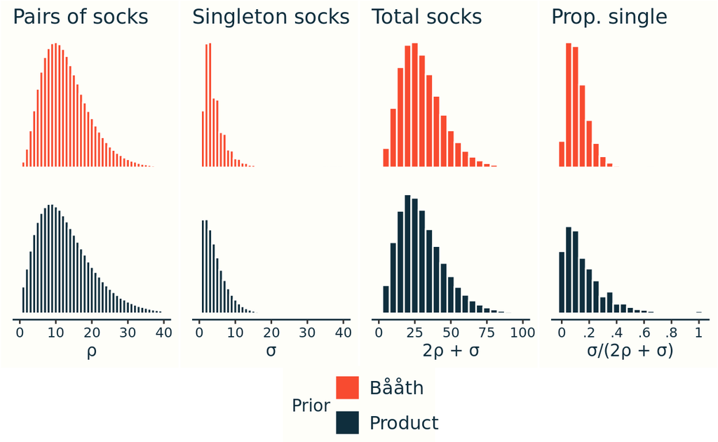

| Measure | Prior | 10% | 25% | 50% | 75% | 90% |
| --- | --- | --- | --- | --- | --- | --- |
| Total socks | Bååth | 13 | 19 | 28 | 38 | 50 |
|  | Product | 12 | 18 | 27 | 39 | 52 |
| Pairs of socks | Bååth | 5 | 8 | 12 | 17 | 22 |
|  | Product | 4 | 7 | 12 | 17 | 24 |
| Singleton socks | Bååth | 1 | 2 | 3 | 5 | 8 |
|  | Product | 0 | 1 | 3 | 6 | 9 |
| Proportion single | Bååth | 0.03 | 0.06 | 0.1 | 0.16 | 0.22 |
|  | Product | 0 | 0.05 | 0.12 | 0.23 | 0.37 |

Density

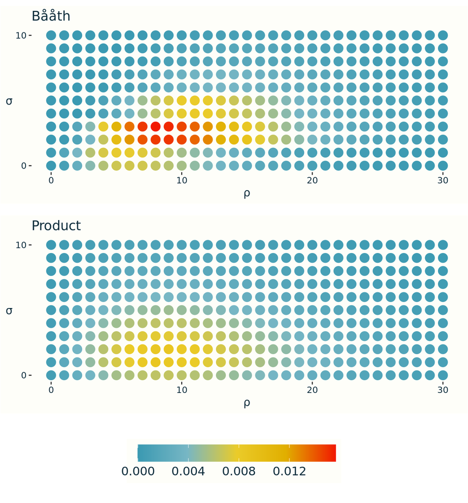

Comparison of Bååth’s Prior and the Product Prior.

The marginal distributions align closely, with the exception of the proportion of singleton socks which is more dispersed for the product prior. This is visible in the (empirical) density plot where Rasmus’ prior clearly has a sharper peak, and is less dispersed in the $\sigma$-axis.

The density plot also shows that the product prior is *smoother* over the parameter space - this is to be expected as defining Rasmus’ prior requires a rounding/floor calculation (which is itself not smooth) to separate the total socks into pairs/singletons.

Finally we can go ahead and derive the posterior using Bayes rule. The animation below shows how the posterior distribution changes with the observation of each additional distinct sock, up to $d=11$.

```r
# define the log product prior
log_product_prior <- function(rho, sigma, r_rho, p_rho, r_sigma, p_sigma){

  if(2*rho + sigma > 300){
    log_prior <- -Inf
  }
  else{
    # relies on the fact that variables r_rho, etc. have been defined in the global
    # environment... This isn't really best practice.
    log_prior <- dnbinom(rho, mu = mu_rho, size = r_rho, log = TRUE) + dnbinom(sigma, mu = mu_sigma, size = r_sigma, log = TRUE)
  }

  return(log_prior)
}

# calculate posterior grid for each of d = 0,...,11 for animation
iterated_posterior_grid <- map(0:11, .f =function(d){

  if(d == 0){
    posterior_grid <- calculate_sock_grid(100, 100,
        log_likelihood = NULL,
        log_prior = function(rho,sigma){log_product_prior(rho,sigma, r_rho, p_rho, r_sigma, p_sigma)}
      ) %>%
      filter(rho <= 30, sigma <= 20) %>%
      mutate(posterior =prior) %>%
      add_column(d = d, .before = 0)
  } else {
    posterior_grid <- calculate_sock_grid(100, 100,
        log_likelihood = function(rho,sigma){baath_log_likelihood(rho,sigma,d=d)},
        log_prior = function(rho,sigma){log_product_prior(rho,sigma, r_rho, p_rho, r_sigma, p_sigma)}
      ) %>%
      filter(rho <= 30, sigma <= 20) %>%
      add_column(d = d, .before = 0)
  }

  return(posterior_grid)
}) %>% bind_rows()

# actual posterior grid
posterior_grid <- iterated_posterior_grid %>% filter(d==11)
```

Total Socks

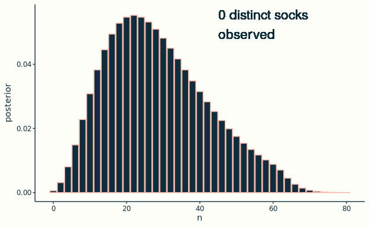

[output not shown]

Posterior Grid

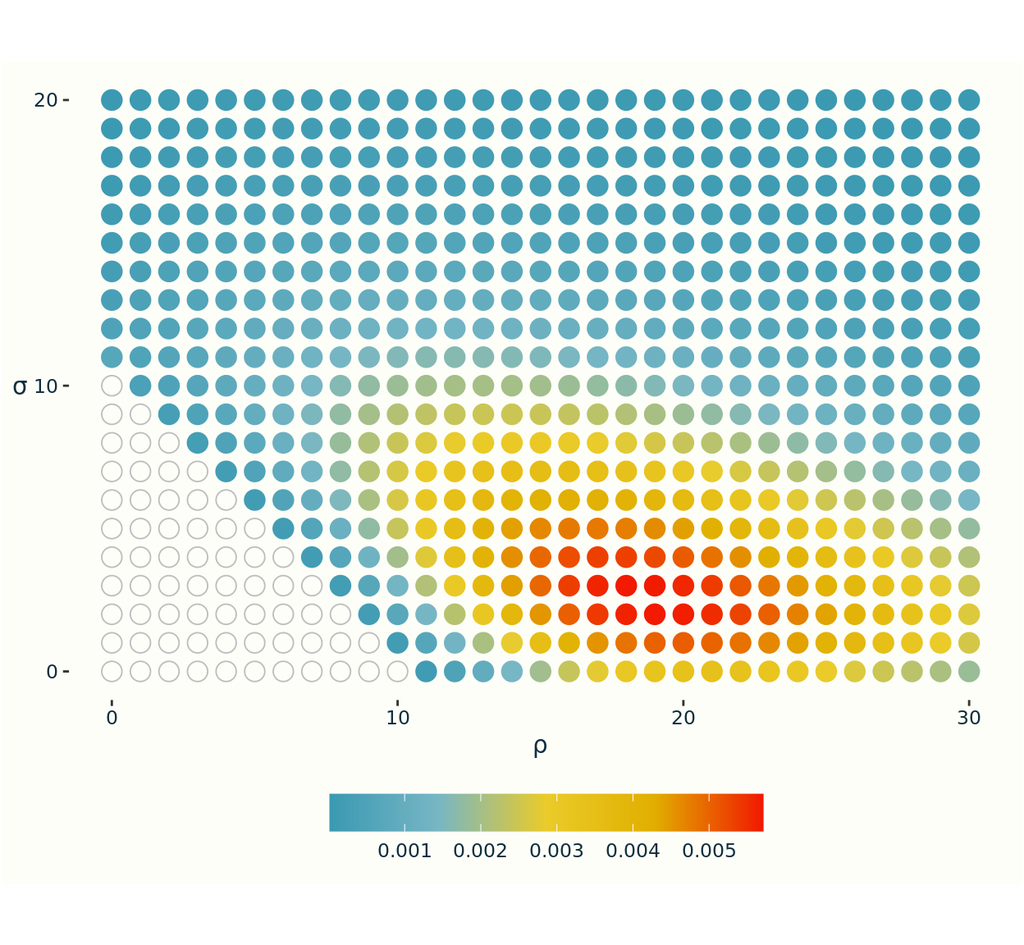

## Acknowledgments

This post was inspired by Karl Broman’s [tweet](https://twitter.com/kwbroman/status/523221976001679360?ref_src=twsrc%5Etfw), and Rasmus Bååth’s [analysis](http://www.sumsar.net/blog/2014/10/tiny-data-and-the-socks-of-karl-broman/).

Computation has been done using R.

## Computational Considerations

In practice we use a couple of *tricks* when computing the likelihood function: avoiding the risk of encountering integer overflow when working with large sums of binomial coefficients.

The first trick is probably familiar: rather than working with the likelihood, we’ll use the *log-likelihood*. The log-likelihood for Bååth’s model is:

$$l(d|\rho,\sigma) = -\log \textstyle{\binom{2\rho + \sigma}{d}} + \log \bigg(\textstyle \sum_{j=0}^{\sigma} 2^{d-j} \binom{\sigma}{j} \binom{\rho}{d-j}\bigg)$$

If we naively go ahead and calculate that sum and then take logs - then we won’t avoid the risk of overflow at all: we’d still calculate a sum of large integers, and taking the logarithm becomes an after thought.

What we really want to do is take the logarithm of the terms *inside* the summation - which will return values well within computational comfort zone. That is we want to turn a computation of the form $\log \left( x_1 + \cdots + x_n\right)$ into a calculation in $\log(x_1),\ldots, \log(x_n)$.

This is where trick number two comes in: the *log-sum-exp* trick.

Log-Sum-Exp Trick Given $x_1,\ldots,x_n > 0$, let $l_k = \log(x_k)$ and $l^* = \max_k l_k$. Then

$$\log(x_1 + \cdots + x_n) = l^* + \log \bigg ( \exp(l_1 - l^*) + \cdots + \exp(l_n - l^*)\bigg)$$

Example Given $x_1,\ldots,x_n > 0$, let $l_k = \log(x_k)$ and $l^* = \max_k l_k$. Then

$$\log(x_1 + \cdots + x_n) = l^* + \log \bigg ( \exp(l_1 - l^*) + \cdots + \exp(l_n - l^*)\bigg)$$

#### Example: $\bf{\rho = 30, \, \sigma = 2, \,d = 11}$.

This particular set of parameters admits a relatively concise likelihood, which will help us to write the complete formulae, starting with the log-likelihood:

$$l(11 | 2,30) = -\log \textstyle \binom{62}{11} + \log \bigg(2^{11} \binom{2}{0}\binom{30}{11} + 2^{10} \binom{2}{1}\binom{30}{10} + 2^{9} \binom{2}{2}\binom{30}{9} \bigg).$$

If we do this by brute force, using R to evaluate each of the powers, and binomial coefficients this becomes:

$$\begin{align}
l(11|2,30) & = -\log 508271323092 \\
& \qquad + \log \big (
111876710400 + 61532190720 + 7325260800
\big) \\
& = - 26.95 + 25.92 \\
& = -1.034
\end{align}$$

And back on the natural scale, that implies a likelihood of $L(11 |2,30) \approx 0.36$.

The bit that feels uncomfortable there is the sum of all those +10 digit numbers - and in real cases we could be summing more terms - each with more digits. So now let’s see how that looks using the log-sum-exp trick.

As per the statement above, we’ll first calculate the log of each of the terms (and include the denominator term, denoted $A$ here, which we’ll need for the full calculation):

$$\begin{align}
\textstyle \log \binom{62}{11} & = A \approx 26.9543 \\
\textstyle \log 2^{11} \binom{2}{0}\binom{30}{11} &= l_1 \approx 25.4407 \\
\textstyle \log 2^{10} \binom{2}{1}\binom{30}{10} &= l_2 \approx 24.8428 \\
\textstyle \log 2^{9} \binom{2}{2}\binom{30}{9} &= l_3 \approx 22.7146 \\
\end{align}$$
The maximum is $l^* = l_1$, and we can go ahead and apply the trick:
$$\begin{align}
l(11|2,30) & = - A + l^* + \log \big ( e^{l_1 - l^*} + e^{l_2 - l^*} + e^{l_3 - l^*}\big) \\
& = -1.514 + \log \big( e^{0} + e^{-0.5978} + e^{-2.726} \big) \\
& = -1.514 + \log \big( 1+ {0.55} + {0.06548} \big) \\
& = -1.514 + 0.4796 \\
& = -1.034
\end{align}$$

As expected we get exactly the same result - with the benefit that the largest value we used in any of the sums was $A \approx 26.95$.

Proof Given $x_1,\ldots,x_n > 0$, let $l_k = \log(x_k)$ and $l^* = \max_k l_k$. Then

$$\log(x_1 + \cdots + x_n) = l^* + \log \bigg ( \exp(l_1 - l^*) + \cdots + \exp(l_n - l^*)\bigg)$$

#### Proof

The trick itself follows some from some fairly routine manipulation of exponentials. In the below, we have $x_k,\,l_k$ defined as above, and let $A$ be any constant:

$$\begin{align*}
x_1 + \cdots + x_n & = \exp( \log x_1) + \cdots + \exp( \log x_n) \\
& = \exp(l_1) + \cdots + \exp(l_n) \\
& = \exp(A) \bigg(\exp(l_1 - A) + \cdots + \exp (l_n - A) \bigg)
\end{align*}$$
Taking logarithms of both sides

$$\log(x_1 + \cdots + x_n) = A + \log \bigg ( \exp(l_1 - A) + \cdots + \exp(l_n - A)\bigg),$$
and the trick follows by choosing $A = l^* = \max_k l_k$.

Importantly subtracting the maximum guarantees that each of the terms to be exponentiated satisfies $l_k - l^* \leq 0$, and hence each exponential is bounded above by 1, avoiding any calculations at the limits of machine precision.

## Bååth’s Prior

Rasmus took the approach of defining the prior distribution in terms of a distribution on the total number of socks and the proportion of these that are singletons.

For Rasmus this choice doesn’t create an issues, as its perfectly easy to sample sample from this prior, and hence to conduct ABC. However as we are looking to do exact Bayesian inference, we have to derive the explicit formula for the prior - and that isn’t trivial.

It is, however, doable and leads to the following formula:

$$P(\rho, \sigma) = P_{\mu, \tau}(2\rho + \sigma) \left\{ F_{\alpha,\beta}\left( \frac{2\rho + 1}{2 \lfloor \rho + \sigma/2\rfloor}\right) - F_{\alpha,\beta}\left( \frac{2\rho - 1}{2 \lfloor \rho + \sigma/2\rfloor}\right) \right\}$$

## Utility Functions

```r
# function to calculate grid of log posterior probabilities.
#   - if prior_func = NULL returns the likelihood,
#   - if likelihood_func = NULL returns the prior distribution
calculate_sock_grid <- function(rho_max,sigma_max, log_likelihood = NULL, log_prior = NULL){

  if(is.null(log_likelihood) & is.null(log_prior)){
    stop("At least one of log_likelihood or log_prior must be provided")
  }

  # initialise grid
  grid <- crossing(
      rho = 0:rho_max,
      sigma = 0:sigma_max,
      log_likelihood = NA_real_,
      log_prior = NA_real_,
      log_posterior = NA_real_
    ) %>% rowwise()


  # populate prior/likelihood
  if(!is.null(log_likelihood)){
    grid <- grid %>% mutate(log_likelihood = log_likelihood(rho,sigma))
  }

  if(!is.null(log_prior)){
    grid <- grid %>% mutate(log_prior = log_prior(rho,sigma))
  }

  # populate posterior, first calculating without the additive constant, Z, then
  # evaluating this and adding.
  grid <- grid %>% mutate(prop_log_posterior = log_likelihood + log_prior)

  log_Z <- logSumExp(grid$prop_log_posterior)

  grid <- grid %>%
    mutate(log_posterior = -log_Z + prop_log_posterior) %>%
    select(-prop_log_posterior)

  # calculate non-log terms
  grid <- grid %>%
    mutate(across(starts_with("log_"), ~exp(.), .names = "exp_{col}")) %>%
    rename_with(~str_remove(.,"exp_log_"))

  return(grid)
}

plot_sock_grid <- function(grid, var){

  var_name <- rlang::as_name(enquo(var))

  if(str_detect(var_name, "log")){

    filled_grid <- grid %>% filter(!is.infinite({{var}}))
    empty_grid <- grid %>% filter(is.infinite({{var}}))
  } else {
    filled_grid <- grid %>% filter(({{var}} != 0))
    empty_grid <- grid %>% filter(({{var}} == 0))
  }

  p <- ggplot() +
    geom_point(data =filled_grid,aes(x = rho, y = sigma, color ={{var}}), size =4) +
    geom_point(data = empty_grid, aes(x = rho, y = sigma, ), color = "grey", shape = 1, size =4) +
    scale_x_continuous(breaks = seq(0,max(grid$rho),by=10)) +
    scale_y_continuous(breaks = seq(0,max(grid$sigma),by=10)) +
    scale_color_gradientn(
      colours = wesanderson::wes_palette("Zissou1", 1000, type = "continuous"),
      name = "") +
    coord_fixed() +
    labs(x = "ρ", y = "σ") +
    theme(
      axis.title.y = element_text(angle = 0, vjust = 0.5),
      axis.line = element_blank(), legend.key.width = unit(1.4, "cm")
    )

 return(p)
}
```